# Appendix: model results and supplementary plots

Gigi Lovicu and Ivan Aguilar

20/12/2021

The theoretical r2 graph allows us to perform prior elicitation on our g selection for our BMS model. Setting g with this prior elicitation ensures that it encodes prior beliefs that are minimally sensible. Our selected value is g = 0.01

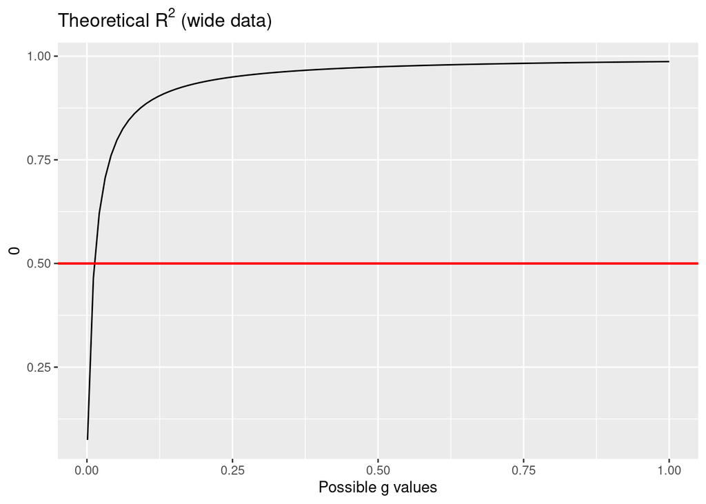

We run a full set of diagnostics for our BMS model to assess convergence. We ran 5000 iterations and in summary we see no evidence that the chain didn’t converge. The marginal inclusion probabilities graph shows in red the estimates with >.90 posterior probability (top left). The precision on the posterior inclusion probabilities at each iteration looks stable from 2000 iterations onward (top right). Model size and log posterior model probability also stabilizes nicely throughout the full diagnostics (bottom)

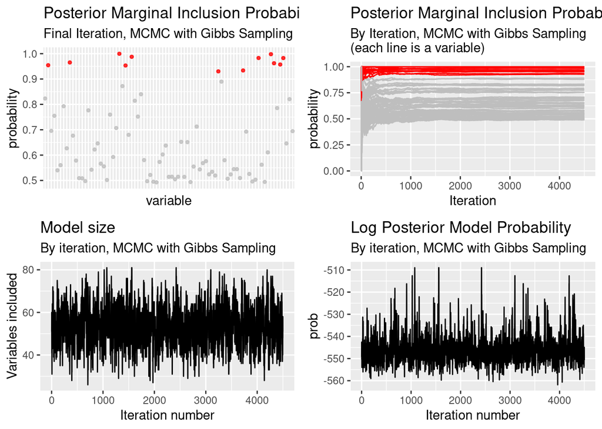

In the graphics below we see the full list of coefficients for our player data (wide data) for the following models:

- Lasso: marked in red are the statistically significant coefficients at 10% or below
- BMS: marked in red are the coefficients with a marginal posterior probability greater than 0.9

In the main body of our study we normally only review the significant coefficients for these models, so here we post the full list for informative purposes.

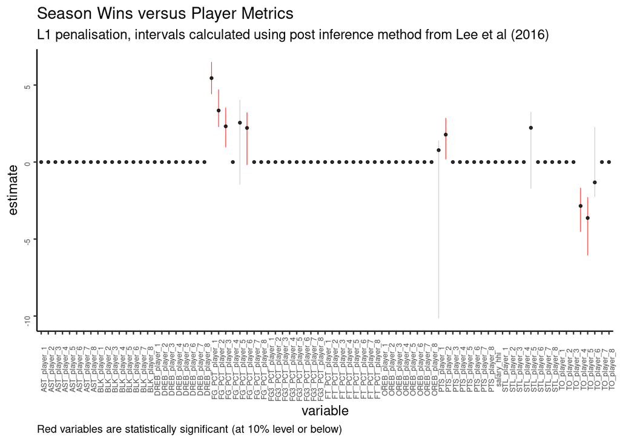

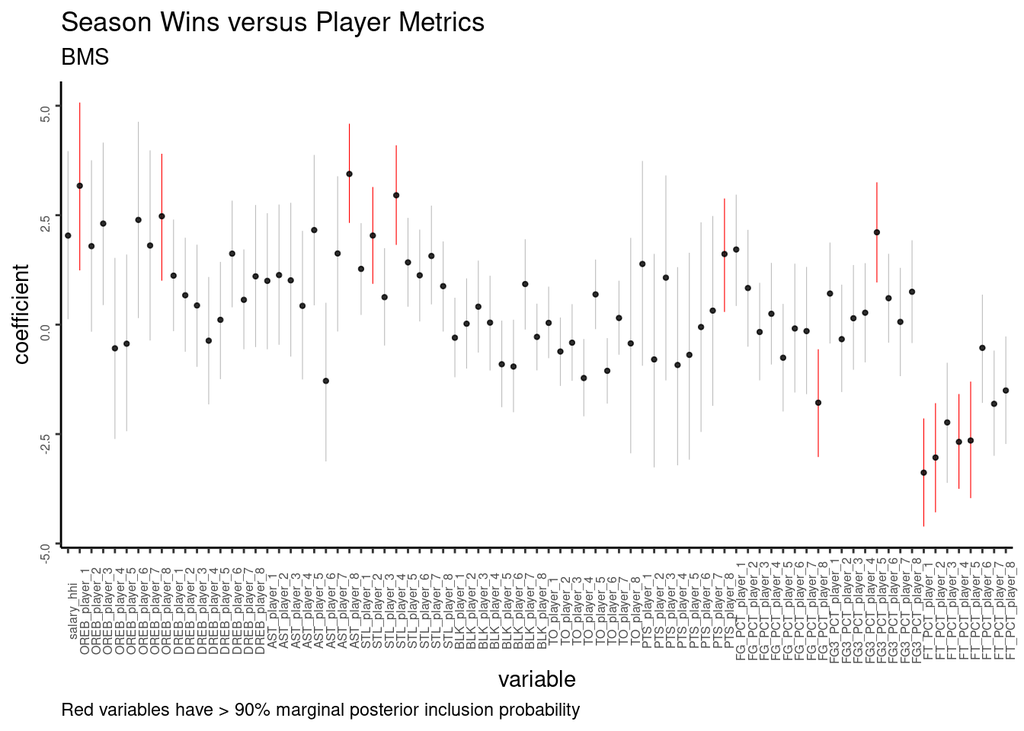

The full list of coefficients and resulting r-squared result for our OLS model on the team-level data (wide) is shown below.

```
##
## Call:
## lm(formula = paste0("win_flag ", season_model) %>% as.formula(),
##     data = data_season_wide)
##
## Residuals:
##     Min      1Q  Median      3Q     Max
## -28.127  -7.331  -0.811   6.736  32.592
##
## Coefficients:
##                  Estimate Std. Error t value Pr(>|t|)
## (Intercept)      43.69886    1.07862  40.514  < 2e-16 ***
## salary_hhi       -2.23423    0.70632  -3.163 0.001716 **
## OREB_player_1    -0.54811    1.54735  -0.354 0.723413
## OREB_player_2     1.74091    1.49280   1.166 0.244435
## OREB_player_3    -1.00395    1.56136  -0.643 0.520706
## OREB_player_4     1.35051    1.50592   0.897 0.370525
## OREB_player_5    -1.16288    1.48537  -0.783 0.434295
## OREB_player_6    -0.83867    1.51255  -0.554 0.579658
## OREB_player_7    -0.08740    1.59438  -0.055 0.956317
## OREB_player_8     0.41411    1.44018   0.288 0.773894
## DREB_player_1     1.37811    1.04277   1.322 0.187287
## DREB_player_2     1.24701    1.12144   1.112 0.267018
## DREB_player_3     1.41404    1.15511   1.224 0.221827
## DREB_player_4     1.28098    1.29349   0.990 0.322794
## DREB_player_5     0.54614    1.28378   0.425 0.670828
## DREB_player_6     2.70361    1.35091   2.001 0.046234 *
## DREB_player_7    -1.60843    1.41607  -1.136 0.256907
## DREB_player_8     2.02213    1.31614   1.536 0.125464
## AST_player_1      2.56333    1.22444   2.093 0.037124 *
## AST_player_2      3.97566    1.18028   3.368 0.000852 ***
## AST_player_3      2.25612    1.29262   1.745 0.081917 .
## AST_player_4      2.90024    1.25375   2.313 0.021367 *
## AST_player_5     -0.68360    1.31084  -0.521 0.602393
## AST_player_6     -0.52923    1.32167  -0.400 0.689124
## AST_player_7      3.00537    1.44713   2.077 0.038650 *
## AST_player_8      2.27452    1.37879   1.650 0.100033
## STL_player_1      0.89285    0.82054   1.088 0.277393
## STL_player_2     -0.40742    0.82282  -0.495 0.620845
## STL_player_3      0.17991    0.83527   0.215 0.829606
```

[output cut: 44 more lines]

```
## FG3_PCT_player_8  1.17185    0.95079   1.233 0.218700
## FT_PCT_player_1  -0.35363    0.93653  -0.378 0.705989
## FT_PCT_player_2   0.05605    0.99901   0.056 0.955291
## FT_PCT_player_3  -0.76859    0.97083  -0.792 0.429157
## FT_PCT_player_4  -0.51540    0.93958  -0.549 0.583719
## FT_PCT_player_5  -1.53372    1.00483  -1.526 0.127950
## FT_PCT_player_6   0.87316    0.87701   0.996 0.320223
## FT_PCT_player_7  -1.32479    0.95888  -1.382 0.168097
## FT_PCT_player_8   0.19307    1.05918   0.182 0.855477
## ---
## Signif. codes:  0 '***' 0.001 '**' 0.01 '*' 0.05 '.' 0.1 ' ' 1
##
## Residual standard error: 12 on 308 degrees of freedom
## Multiple R-squared:  0.5765, Adjusted R-squared:  0.4651
## F-statistic: 5.176 on 81 and 308 DF,  p-value: < 2.2e-16
```

Below we show the full list of coefficients and standard errors (calculated using the method in Lee et al (2016)) for our Lasso BIC model (with the optimal lambda) on the team-level data (wide).

```
##                    estimate      ci.low     ci.up       pvalue
## salary_hhi        0.0000000   0.0000000  0.000000           NA
## OREB_player_1     0.0000000   0.0000000  0.000000           NA
## OREB_player_2     0.0000000   0.0000000  0.000000           NA
## OREB_player_3     0.0000000   0.0000000  0.000000           NA
## OREB_player_4     0.0000000   0.0000000  0.000000           NA
## OREB_player_5     0.0000000   0.0000000  0.000000           NA
## OREB_player_6     0.0000000   0.0000000  0.000000           NA
## OREB_player_7     0.0000000   0.0000000  0.000000           NA
## OREB_player_8     0.0000000   0.0000000  0.000000           NA
## DREB_player_1     0.0000000   0.0000000  0.000000           NA
## DREB_player_2     0.0000000   0.0000000  0.000000           NA
## DREB_player_3     0.0000000   0.0000000  0.000000           NA
## DREB_player_4     0.0000000   0.0000000  0.000000           NA
## DREB_player_5     0.0000000   0.0000000  0.000000           NA
## DREB_player_6     0.0000000   0.0000000  0.000000           NA
## DREB_player_7     0.0000000   0.0000000  0.000000           NA
## DREB_player_8     0.0000000   0.0000000  0.000000           NA
## AST_player_1      0.0000000   0.0000000  0.000000           NA
## AST_player_2      0.0000000   0.0000000  0.000000           NA
## AST_player_3      0.0000000   0.0000000  0.000000           NA
## AST_player_4      0.0000000   0.0000000  0.000000           NA
## AST_player_5      0.0000000   0.0000000  0.000000           NA
## AST_player_6      0.0000000   0.0000000  0.000000           NA
## AST_player_7      0.0000000   0.0000000  0.000000           NA
## AST_player_8      0.0000000   0.0000000  0.000000           NA
## STL_player_1      0.0000000   0.0000000  0.000000           NA
## STL_player_2      0.0000000   0.0000000  0.000000           NA
## STL_player_3      0.0000000   0.0000000  0.000000           NA
## STL_player_4      0.0000000   0.0000000  0.000000           NA
## STL_player_5      2.2255383  -1.7257881  3.252182 1.777314e-01
## STL_player_6      0.0000000   0.0000000  0.000000           NA
## STL_player_7      0.0000000   0.0000000  0.000000           NA
## STL_player_8      0.0000000   0.0000000  0.000000           NA
## BLK_player_1      0.0000000   0.0000000  0.000000           NA
## BLK_player_2      0.0000000   0.0000000  0.000000           NA
## BLK_player_3      0.0000000   0.0000000  0.000000           NA
## BLK_player_4      0.0000000   0.0000000  0.000000           NA
## BLK_player_5      0.0000000   0.0000000  0.000000           NA
## BLK_player_6      0.0000000   0.0000000  0.000000           NA
```

[output cut: 27 more lines]

```
## FG3_PCT_player_2  0.0000000   0.0000000  0.000000           NA
## FG3_PCT_player_3  0.0000000   0.0000000  0.000000           NA
## FG3_PCT_player_4  0.0000000   0.0000000  0.000000           NA
## FG3_PCT_player_5  0.0000000   0.0000000  0.000000           NA
## FG3_PCT_player_6  0.0000000   0.0000000  0.000000           NA
## FG3_PCT_player_7  0.0000000   0.0000000  0.000000           NA
## FG3_PCT_player_8  0.0000000   0.0000000  0.000000           NA
## FT_PCT_player_1   0.0000000   0.0000000  0.000000           NA
## FT_PCT_player_2   0.0000000   0.0000000  0.000000           NA
## FT_PCT_player_3   0.0000000   0.0000000  0.000000           NA
## FT_PCT_player_4   0.0000000   0.0000000  0.000000           NA
## FT_PCT_player_5   0.0000000   0.0000000  0.000000           NA
## FT_PCT_player_6   0.0000000   0.0000000  0.000000           NA
## FT_PCT_player_7   0.0000000   0.0000000  0.000000           NA
## FT_PCT_player_8   0.0000000   0.0000000  0.000000           NA
```

In the table below we show all the coefficients estimates for our BMS model on the team-level data (wide).

```
## # A tibble: 82 × 5
##    variable      estimate  X2.5. X97.5. margpp
##    <chr>            <dbl>  <dbl>  <dbl>  <dbl>
##  1 intercept       44.2   42.7   45.8    1
##  2 salary_hhi      -1.78  -3.02  -0.562  0.934
##  3 OREB_player_1   -0.429 -2.94   1.98   0.555
##  4 OREB_player_2    1.39  -0.939  3.74   0.713
##  5 OREB_player_3   -0.795 -3.26   1.62   0.544
##  6 OREB_player_4    1.07  -1.27   3.41   0.568
##  7 OREB_player_5   -0.922 -3.21   1.31   0.576
##  8 OREB_player_6   -0.691 -3.08   1.64   0.524
##  9 OREB_player_7   -0.055 -2.45   2.34   0.534
## 10 OREB_player_8    0.32  -1.85   2.48   0.520
## # … with 72 more rows
```

We show here the top 10 BMS models with their posterior probabilities and selected features

```
##                                                                                                                                                                                                                                      modelid
## 1  1,2,3,4,5,6,7,8,9,10,11,12,13,14,15,16,17,18,19,20,21,22,23,24,25,26,27,28,29,30,31,32,33,34,35,36,37,38,39,40,41,42,43,44,45,46,47,48,49,50,51,52,53,54,55,56,57,58,59,60,61,62,63,64,65,66,67,68,69,70,71,72,73,74,75,76,77,78,79,80,81
## 2     1,2,3,4,5,6,7,8,9,10,11,12,13,14,15,16,17,18,19,20,21,22,23,24,25,26,27,28,29,30,31,32,33,34,35,36,37,38,39,40,41,42,43,44,45,46,47,48,49,50,51,52,53,54,55,56,57,58,59,60,61,62,63,64,65,66,67,68,69,70,71,72,73,74,76,77,78,79,80,81
## 3     1,2,3,4,5,6,7,8,9,10,11,12,13,14,15,16,17,18,19,20,21,22,23,24,25,26,27,28,29,30,31,32,33,34,35,36,37,38,39,40,41,42,43,44,45,46,47,48,49,50,51,52,53,54,55,56,57,58,59,60,61,62,63,64,65,66,67,68,69,70,71,72,73,74,75,76,77,78,79,80
## 4     1,2,3,4,5,6,7,8,9,10,11,12,13,14,15,16,17,18,19,20,21,22,23,24,25,26,27,28,29,30,31,32,33,34,35,36,37,38,39,40,41,42,43,44,45,46,47,48,49,50,51,52,53,55,56,57,58,59,60,61,62,63,64,65,66,67,68,69,70,71,72,73,74,75,76,77,78,79,80,81
## 5    1,2,3,4,5,6,7,8,10,11,12,13,14,15,16,17,18,19,20,21,22,23,24,25,26,27,28,29,30,31,32,33,34,35,36,37,38,39,40,41,42,43,44,45,46,47,48,49,50,51,52,53,54,55,56,57,58,59,60,61,62,63,64,65,66,67,68,69,70,71,72,73,74,75,76,77,78,79,80,81
## 6    1,3,4,5,6,7,8,9,10,11,12,13,14,15,16,17,18,19,20,21,22,23,24,25,26,27,28,29,30,31,32,33,34,35,36,37,38,39,40,41,42,43,44,45,46,47,48,49,50,51,52,53,54,55,56,57,58,59,60,61,62,63,64,65,66,67,68,69,70,71,72,73,74,75,76,77,78,79,80,81
## 7     1,2,3,4,5,6,7,8,9,10,11,12,13,14,15,16,17,18,19,20,21,22,23,24,25,26,27,28,29,30,31,32,33,34,35,36,37,39,40,41,42,43,44,45,46,47,48,49,50,51,52,53,54,55,56,57,58,59,60,61,62,63,64,65,66,67,68,69,70,71,72,73,74,75,76,77,78,79,80,81
## 8     1,2,3,4,5,6,7,8,9,10,11,12,13,14,15,16,17,18,19,20,21,22,23,24,25,26,27,28,29,30,31,32,33,34,35,36,37,38,39,40,42,43,44,45,46,47,48,49,50,51,52,53,54,55,56,57,58,59,60,61,62,63,64,65,66,67,68,69,70,71,72,73,74,75,76,77,78,79,80,81
## 9    1,2,3,4,5,7,8,9,10,11,12,13,14,15,16,17,18,19,20,21,22,23,24,25,26,27,28,29,30,31,32,33,34,35,36,37,38,39,40,41,42,43,44,45,46,47,48,49,50,51,52,53,54,55,56,57,58,59,60,61,62,63,64,65,66,67,68,69,70,71,72,73,74,75,76,77,78,79,80,81
## 10      1,2,3,4,5,6,7,9,10,11,12,13,14,15,16,17,18,19,20,21,22,23,24,25,26,27,28,29,30,31,32,33,34,35,37,38,39,40,41,42,43,44,45,46,47,48,49,50,51,52,53,54,55,56,57,58,59,60,61,62,63,64,65,66,67,68,69,70,71,72,73,74,75,76,77,78,79,80,81
##    family           pp
## 1  normal 0.8295828699
## 2  normal 0.0226429820
## 3  normal 0.0223759821
## 4  normal 0.0219864553
## 5  normal 0.0219439173
## 6  normal 0.0215767544
## 7  normal 0.0212619283
## 8  normal 0.0178181912
## 9  normal 0.0178060579
## 10 normal 0.0009788782
```

The full list of coefficients and resulting r-squared result for our OLS model on the player-level data (long) is shown below.

```
##
## Call:
## lm(formula = paste0("WS ", season_model_interactions) %>% as.formula(),
##     data = data_season_qr)
##
## Residuals:
##    Min     1Q Median     3Q    Max
## -6.392 -1.190 -0.150  1.068  7.912
##
## Coefficients:
##                      Estimate Std. Error t value Pr(>|t|)
## (Intercept)           4.42983    0.03865 114.622  < 2e-16 ***
## OREB                  0.15519    0.07503   2.068 0.038707 *
## DREB                  0.77860    0.06126  12.709  < 2e-16 ***
## AST                   1.57322    0.06132  25.658  < 2e-16 ***
## STL                   0.44625    0.03973  11.233  < 2e-16 ***
## BLK                   0.32228    0.05012   6.430 1.50e-10 ***
## TO                   -1.49581    0.05832 -25.648  < 2e-16 ***
## PTS                   1.55486    0.05281  29.444  < 2e-16 ***
## FG_PCT                1.27756    0.05063  25.233  < 2e-16 ***
## FG3_PCT               0.25207    0.04779   5.275 1.43e-07 ***
## FT_PCT                0.37836    0.04889   7.739 1.40e-14 ***
## salary_share          0.17302    0.04183   4.136 3.63e-05 ***
## salary_hhi           -0.13389    0.03706  -3.613 0.000308 ***
## salary_total         -0.31183    0.04152  -7.511 7.88e-14 ***
## OREB:salary_share     0.26066    0.07684   3.392 0.000703 ***
## DREB:salary_share    -0.08862    0.05631  -1.574 0.115638
## AST:salary_share      0.10180    0.06098   1.670 0.095128 .
## STL:salary_share      0.11789    0.04121   2.861 0.004257 **
## BLK:salary_share      0.03320    0.04815   0.690 0.490462
## TO:salary_share      -0.10773    0.05626  -1.915 0.055627 .
## PTS:salary_share      0.17759    0.04729   3.755 0.000177 ***
## FG_PCT:salary_share   0.21637    0.04957   4.365 1.32e-05 ***
## FG3_PCT:salary_share  0.09942    0.04862   2.045 0.040962 *
## FT_PCT:salary_share   0.18743    0.04840   3.872 0.000110 ***
## ---
## Signif. codes:  0 '***' 0.001 '**' 0.01 '*' 0.05 '.' 0.1 ' ' 1
##
## Residual standard error: 1.84 on 2781 degrees of freedom
## Multiple R-squared:  0.6393, Adjusted R-squared:  0.6363
## F-statistic: 214.3 on 23 and 2781 DF,  p-value: < 2.2e-16
```

The full list of coefficients for our quantile regression model on the player-level data (long) is shown below.

```
##
## Call: rq(formula = formula_long, tau = 0.5, data = data_season_qr)
##
## tau: [1] 0.5
##
## Coefficients:
##                      Value     Std. Error t value   Pr(>|t|)
## (Intercept)            4.20647   0.04581   91.81988   0.00000
## OREB                   0.27855   0.07494    3.71687   0.00021
## DREB                   0.69309   0.06188   11.20092   0.00000
## AST                    1.54925   0.06564   23.60073   0.00000
## STL                    0.43858   0.03832   11.44523   0.00000
## BLK                    0.31148   0.04939    6.30659   0.00000
## TO                    -1.56332   0.05389  -29.00907   0.00000
## PTS                    1.34602   0.04930   27.30153   0.00000
## FG_PCT                 1.19439   0.04885   24.44997   0.00000
## FG3_PCT                0.19870   0.04141    4.79835   0.00000
## FT_PCT                 0.41551   0.04344    9.56546   0.00000
## salary_share           0.27173   0.04459    6.09339   0.00000
## salary_hhi            -0.14022   0.03404   -4.11942   0.00004
## salary_total          -0.33101   0.03333   -9.93174   0.00000
## OREB:salary_share      0.31114   0.07603    4.09227   0.00004
## DREB:salary_share     -0.04441   0.05466   -0.81251   0.41657
## AST:salary_share       0.16030   0.06297    2.54578   0.01096
## STL:salary_share       0.06526   0.03649    1.78845   0.07381
## BLK:salary_share      -0.02863   0.04941   -0.57945   0.56233
## TO:salary_share       -0.16163   0.05128   -3.15167   0.00164
## PTS:salary_share       0.23348   0.04376    5.33573   0.00000
## FG_PCT:salary_share    0.21080   0.04917    4.28741   0.00002
## FG3_PCT:salary_share   0.10087   0.04000    2.52202   0.01172
## FT_PCT:salary_share    0.16169   0.04553    3.55104   0.00039
```

Full summary of the Nested Intercepts hierarchical model is shown below, including all the coefficient estimates for the team data (long)

```
## Linear mixed model fit by REML. t-tests use Satterthwaite's method [
## lmerModLmerTest]
## Formula: model_hm_ts %>% as.formula()
##    Data: data_season_hm %>% dplyr::select(-c(PLAYER_ID, rank))
##
## REML criterion at convergence: 11101.4
##
## Scaled residuals:
##     Min      1Q  Median      3Q     Max
## -3.5698 -0.5874 -0.0394  0.5616  4.2633
##
## Random effects:
##  Groups                   Name        Variance Std.Dev.
##  TEAM_ABBREVIATION:season (Intercept) 0.83363  0.9130
##  season                   (Intercept) 0.05709  0.2389
##  Residual                             2.51639  1.5863
## Number of obs: 2805, groups:  TEAM_ABBREVIATION:season, 360; season, 12
##
## Fixed effects:
##                        Estimate Std. Error         df t value Pr(>|t|)
## (Intercept)           4.475e+00  9.104e-02  1.052e+01  49.153 8.93e-14 ***
## OREB                  1.473e-01  6.884e-02  2.633e+03   2.140 0.032440 *
## DREB                  8.025e-01  5.510e-02  2.552e+03  14.564  < 2e-16 ***
## AST                   1.585e+00  5.576e-02  2.606e+03  28.428  < 2e-16 ***
## STL                   4.719e-01  3.612e-02  2.605e+03  13.064  < 2e-16 ***
## BLK                   3.298e-01  4.456e-02  2.530e+03   7.402 1.82e-13 ***
## TO                   -1.500e+00  5.451e-02  2.668e+03 -27.517  < 2e-16 ***
## PTS                   1.594e+00  4.744e-02  2.567e+03  33.608  < 2e-16 ***
## FG_PCT                1.242e+00  4.714e-02  2.681e+03  26.351  < 2e-16 ***
## FG3_PCT               2.276e-01  4.308e-02  2.580e+03   5.282 1.38e-07 ***
## FT_PCT                4.283e-01  4.442e-02  2.604e+03   9.643  < 2e-16 ***
## salary_share          1.910e-01  3.649e-02  2.469e+03   5.235 1.79e-07 ***
## salary_hhi           -1.246e-01  5.965e-02  3.563e+02  -2.090 0.037370 *
## salary_total         -2.448e-01  7.235e-02  3.016e+02  -3.384 0.000810 ***
## OREB:salary_share     2.571e-01  6.987e-02  2.607e+03   3.680 0.000238 ***
## DREB:salary_share    -1.129e-01  5.096e-02  2.591e+03  -2.214 0.026882 *
## AST:salary_share      5.178e-02  5.557e-02  2.619e+03   0.932 0.351506
## STL:salary_share      1.069e-01  3.705e-02  2.574e+03   2.886 0.003932 **
## BLK:salary_share      8.002e-03  4.371e-02  2.605e+03   0.183 0.854777
## TO:salary_share      -5.886e-02  5.121e-02  2.612e+03  -1.149 0.250515
## PTS:salary_share      9.315e-02  4.315e-02  2.620e+03   2.158 0.030984 *
## FG_PCT:salary_share   2.021e-01  4.481e-02  2.591e+03   4.509 6.80e-06 ***
## FG3_PCT:salary_share  1.229e-01  4.392e-02  2.587e+03   2.798 0.005187 **
## FT_PCT:salary_share   2.000e-01  4.395e-02  2.604e+03   4.552 5.56e-06 ***
## ---
## Signif. codes:  0 '***' 0.001 '**' 0.01 '*' 0.05 '.' 0.1 ' ' 1
```

```
##
## Correlation matrix not shown by default, as p = 24 > 12.
## Use print(x, correlation=TRUE)  or
##     vcov(x)        if you need it
```

Full summary of the Varying Intercepts and Varying Slope for Salary HHI hierarchical model is shown below, including all the coefficient estimates for the team data (long)

```
## Linear mixed model fit by REML. t-tests use Satterthwaite's method [
## lmerModLmerTest]
## Formula: model_hm_slope %>% as.formula()
##    Data: data_season_hm %>% dplyr::select(-c(PLAYER_ID, rank))
##
## REML criterion at convergence: 11280
##
## Scaled residuals:
##     Min      1Q  Median      3Q     Max
## -3.5108 -0.6311 -0.0549  0.5763  4.3324
##
## Random effects:
##  Groups            Name        Variance Std.Dev. Corr
##  TEAM_ABBREVIATION (Intercept) 0.23863  0.4885
##                    salary_hhi  0.14148  0.3761   0.36
##  season            (Intercept) 0.08097  0.2845
##  Residual                      3.04301  1.7444
## Number of obs: 2805, groups:  TEAM_ABBREVIATION, 30; season, 12
##
## Fixed effects:
##                        Estimate Std. Error         df t value Pr(>|t|)
## (Intercept)             4.45916    0.12792   29.16097  34.858  < 2e-16 ***
## OREB                    0.15196    0.07300 2753.75971   2.082 0.037468 *
## DREB                    0.80562    0.05929 2741.24149  13.587  < 2e-16 ***
## AST                     1.59277    0.05957 2757.07809  26.739  < 2e-16 ***
## STL                     0.47640    0.03840 2748.45448  12.406  < 2e-16 ***
## BLK                     0.32294    0.04802 2730.93743   6.725 2.14e-11 ***
## TO                     -1.53581    0.05742 2764.15127 -26.748  < 2e-16 ***
## PTS                     1.58774    0.05090 2743.75821  31.195  < 2e-16 ***
## FG_PCT                  1.27849    0.04957 2760.60512  25.790  < 2e-16 ***
## FG3_PCT                 0.26671    0.04585 2738.92430   5.817 6.68e-09 ***
## FT_PCT                  0.38593    0.04730 2750.22107   8.160 5.04e-16 ***
## salary_share            0.18312    0.03986 2719.23680   4.595 4.53e-06 ***
## salary_hhi             -0.15563    0.08505   22.85409  -1.830 0.080341 .
## salary_total           -0.26386    0.05331 1340.64278  -4.950 8.37e-07 ***
## OREB:salary_share       0.25089    0.07442 2751.76031   3.371 0.000759 ***
## DREB:salary_share      -0.10117    0.05443 2747.42836  -1.859 0.063160 .
## AST:salary_share        0.08273    0.05927 2752.39215   1.396 0.162843
## STL:salary_share        0.12577    0.03943 2734.05062   3.189 0.001442 **
## BLK:salary_share        0.02124    0.04635 2742.03455   0.458 0.646844
## TO:salary_share        -0.07444    0.05438 2750.86863  -1.369 0.171152
## PTS:salary_share        0.11760    0.04584 2756.68258   2.565 0.010360 *
## FG_PCT:salary_share     0.23388    0.04778 2743.15112   4.895 1.04e-06 ***
## FG3_PCT:salary_share    0.09369    0.04669 2739.65275   2.007 0.044870 *
## FT_PCT:salary_share     0.22448    0.04662 2744.51481   4.815 1.55e-06 ***
## ---
## Signif. codes:  0 '***' 0.001 '**' 0.01 '*' 0.05 '.' 0.1 ' ' 1
```

```
##
## Correlation matrix not shown by default, as p = 24 > 12.
## Use print(x, correlation=TRUE)  or
##     vcov(x)        if you need it
```

Below are the results of the ANOVA analysis, with tests for the inclusion of the random-effect terms in the model. The likelihood ratio tests show that the nested intercepts (team:season) should both be included.

```
## ANOVA-like table for random-effects: Single term deletions
##
## Model:
## WS ~ OREB + DREB + AST + STL + BLK + TO + PTS + FG_PCT + FG3_PCT + FT_PCT + salary_share + salary_hhi + salary_total + (1 | TEAM_ABBREVIATION:season) + (1 | season) + OREB:salary_share + DREB:salary_share + AST:salary_share + STL:salary_share + BLK:salary_share + TO:salary_share + PTS:salary_shar…
##                                npar  logLik   AIC    LRT Df Pr(>Chisq)
## <none>                           27 -5550.7 11155
## (1 | TEAM_ABBREVIATION:season)   26 -5712.4 11477 323.37  1     <2e-16 ***
## (1 | season)                     26 -5553.1 11158   4.81  1     0.0283 *
## ---
## Signif. codes:  0 '***' 0.001 '**' 0.01 '*' 0.05 '.' 0.1 ' ' 1
```

And here that the varying intercepts by season and varying salary_hhi slopes by team should both be included.

```
## ANOVA-like table for random-effects: Single term deletions
##
## Model:
## WS ~ OREB + DREB + AST + STL + BLK + TO + PTS + FG_PCT + FG3_PCT + FT_PCT + salary_share + salary_hhi + salary_total + (1 + salary_hhi | TEAM_ABBREVIATION) + (1 | season) + OREB:salary_share + DREB:salary_share + AST:salary_share + STL:salary_share + BLK:salary_share + TO:salary_share + PTS:salar…
##                                                    npar  logLik   AIC   LRT Df
## <none>                                               29 -5640.0 11338
## salary_hhi in (1 + salary_hhi | TEAM_ABBREVIATION)   27 -5655.1 11364 30.24  2
## (1 | season)                                         28 -5656.5 11369 32.94  1
##                                                    Pr(>Chisq)
## <none>
## salary_hhi in (1 + salary_hhi | TEAM_ABBREVIATION)  2.713e-07 ***
## (1 | season)                                        9.507e-09 ***
## ---
## Signif. codes:  0 '***' 0.001 '**' 0.01 '*' 0.05 '.' 0.1 ' ' 1
```